# **Introduction**

Alpine Treeline Ecotones (ATEs) are transitional zones between subalpine Forest and Alpine (tundra) Ecotones (@holtmeierSensitivityResponseNorthern2005, @winingsMappingAlpineTreeline2013), also referred to as upper-treeline (@elliottTreelineEcotones2017) which occur globally (@singhRemoteSensingAlpine2015, @baderGlobalFrameworkLinking2021). The ATE spans between the actual Timberline/Economic Forest Line though the Upper/Physiognomic-Biologic Forest Line and the tree species line which is adjoining the actual Alpine zone (@chhetriRemoteSensingGeographic2019, 1543). The position of the treeline (which is not the same as the tree species line) is influenced by multiple factors at local and regional level, but temperature has been identified as the global driving factor (@kornerReassessmentHighElevation1998, @kornerWorldwideStudyHigh2004, @holtmeierSensitivityResponseNorthern2005, @baderVegetationStructureTemperature2007, @barredocanoImpactsClimateChange2020). The global pattern can be described by spatial patterns in the x-y plane (discrete, diffuse or their variation **Figure 1**, top left) and by changes in tree stature (abrupt, gradual, or their variation **Figure 1**, right) in a multi-dimensional space (@harschTreelineFormPotential2011, @baderGlobalFrameworkLinking2021).

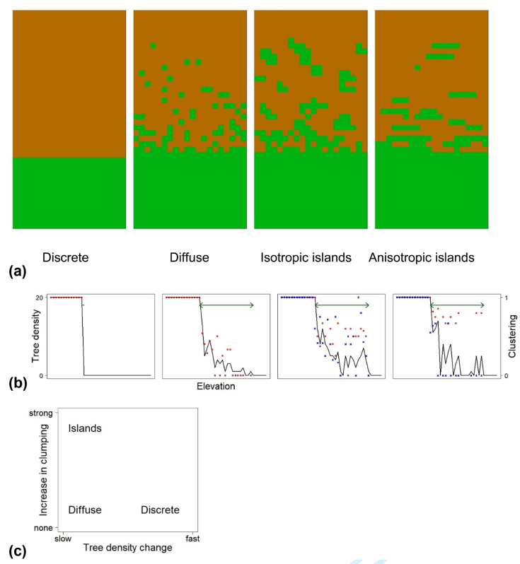

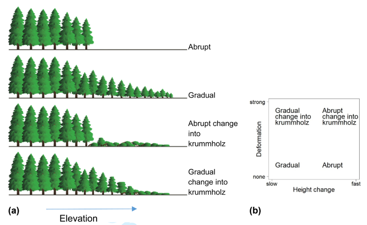

Left: Scheme of the spatial pattern of alpine treelines on the 2D x-y plane. a) Depicts the treeline as seen from above, while b) depicts the profile of the change of the treeline (clustering of islands). c) Represents an abstraction of the pattern of treelines based on tree density change and the clustering of individual trees. Source: Bader et al. (2021), Figure 1. Right: Scheme of (discrete) tree stature/height change responding to change in elevation. a) Vertical cross section. b) Abstraction of tree stature change based on height change and deformation of tree shape. Source: Bader et al. (2021), Figure 2.

Although recognized, the distribution of ATE patterns have neither been mapped, nor been described yet, let alone explained. Earlier studies have identified abrupt, diffuse, island and krummholz spatial patterns of ATEs (@harschAreTreelinesAdvancing2009, @harschTreelineFormPotential2011, **Figure 1 & 2**). As seen, treelines display a high variability and differ in multiple dimensions. A comparison of multiple studies suggest, that different spatial patterns of ATEs reflect fundamental ecological controlling processes and that different ATEs react differently to climate change (@harschTreelineFormPotential2011, Figure 1, **Figure 2**, left.

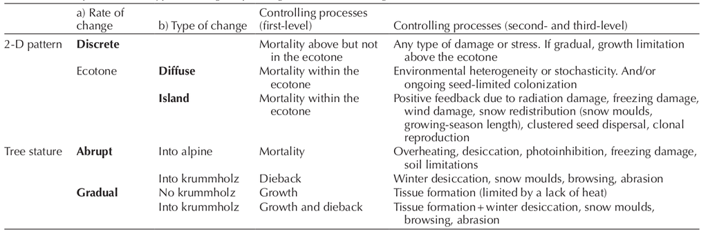

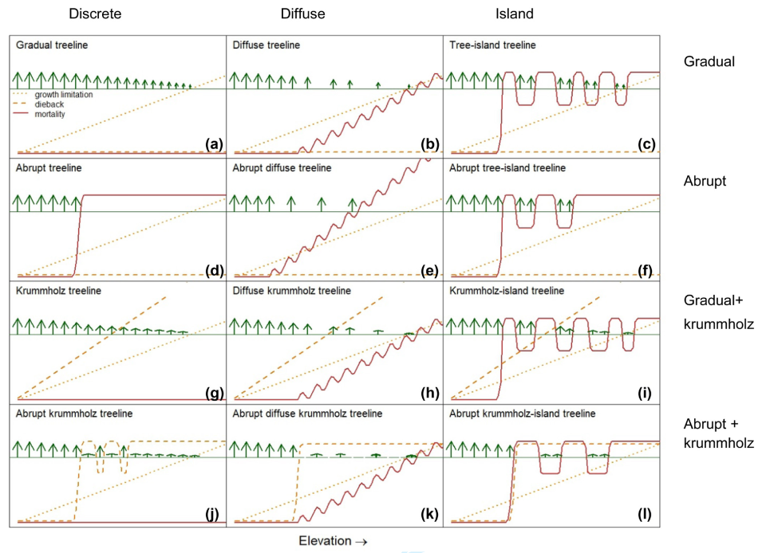

Left: Matrix of 2D spatial pattern, stature change and ecological processes which can contribute to the different types of ATEs. Source: Bader et al. (2021), Table 1. Right: Matrix of the multidimensional state space of treeline forms depicting extreme cases of the different dimensions. Columns represent the spatial patterns in the x-y plane and rows the change in tree stature (size and shape). The lines represents the hypothesized first-level ecological processes behind the patterns along an elevational gradient. The dotted line displays the growth limitation, the dashed line the dieback and the continuous line the mortality. Growth limitation always occurs while dieback only affects if krummholz is involved. Source: Bader et al. (2021), Figure 3.

To better understand and categorize ATEs a standardized description and terminology of spatial patterns has been proposed on hillslope and landscape scale by @baderGlobalFrameworkLinking2021, including hypotheses for the general mechanisms behind the patterns. The terminology and the multidimensional state-space can be most clearly understood from **Figure 2**, right.

After the definition and the characterization of the spatial patterns of ATEs, this methodological project paper delivers a literature overview of ATE research and tree detection by means of Deep Learning in general. This overview (**Chapter 2**) served as a trigger for the reproducible and replicable workflow for tree detection presented in this methodological project paper (mainly in **Chapter 3**). The research questions are addressed at the end of the overview (**Chapter 2**), because the needed expressions are elaborated in that chapter.